# Weighted Balancer Pools: Divergence Loss - Theory and Simulation Results

Armin Satzger, 4 May 2023

## Theory

[Xu et al (2023, p. 34)](https://arxiv.org/pdf/2103.12732.pdf) derive the result of divergence loss for a pool where only a single price $p_k$ changes ($\rho$ denoting the relative change in the exchange rate between $x_1$ and $x_2$) during the time period: $$ IL(\rho) = \dfrac{V'}{V_{held}} - 1= \dfrac{(1+\rho)^{\omega_2}}{1+\omega_2 * \rho} - 1$$

Their result can easily be extended to the case of multiple prices changing. Similar to their result, we can obtain a solution by comparing the values of the pool components in $t_1$ inside and outside a weighted Balancer liquidity pool.

Outside the pool, the total value $V$ ($V_{held}$ denotes the case without IL) would appreciate according to the pool weights $\omega_1, ..., \omega_n$: $$ V_{held} = V + \sum_{k=1}^n V_k * \rho_k = V * (1+ \sum_{k=1}^n \omega_k * \rho_k)$$

Inside the pool, price changes on other (centralized or decentralized) trading venues create arbitrage opportunities. With some additional assumptions (such as assuming zero gas fees on the network and a zero swap fees configuration on the protocol), this resulting arbitrage opportunity and price discrepancy can be assumed to be closed quickly.

The price changes of multiple tokens in the pool can be modelled as a sequential change of the underlying prices chaining together multiple times the value change from $V$ to $V'$ described by Xu et al where, with each price change ($\rho_k$) for token $k$, the pool value is multiplied with $(1+\rho_k)^\omega_k$: $$V'=\dfrac{V'_1}{\omega_1}=\dfrac{r'_1}{\omega_1}=\dfrac{r_1*(1+\rho_1)^{\omega_1}*...*(1+\rho_n)^{\omega_n}}{\omega_1} = \dfrac{r_1}{\omega_1} * \prod_{k=1}^n (1+\rho_k)^k = V * \prod_{k=1}^n (1+\rho_k)^k$$

The impermanent, or divergent, loss is now again simply equal to the relative loss vs holding the initial pool composition outside the pool: $$IL(\rho) = \dfrac{V'}{V_{held}} - 1 = \dfrac{V * \prod_{k=r}^n (1+\rho_k)^k}{V * (1+ \sum_{k=1}^n \omega_k * \rho_k)} - 1 = \dfrac{\prod_{k=1}^n (1+\rho_k)^k}{(1+ \sum_{k=1}^n \omega_k * \rho_k)} - 1 $$

# Data Cleaning and Preparation

The following code cleans and processes historical price data for BAL and ETH tokens obtained from Coingecko. It reads CSV files containing the data, selects relevant columns, renames the price columns, and merges the two DataFrames on the 'snapped_at' column. It then calculates the historical correlation between BAL and ETH prices and derives parameters for modeling future prices via a random walk. Finally, the cleaned and merged DataFrame is saved to a new CSV file.

```python
import pandas as pd

# Load CSV files and clean them
def load_and_clean_csv(file_path, token):
    df = pd.read_csv(file_path, parse_dates=['snapped_at'])
    df = df[['snapped_at', 'price']].rename(columns={'price': f'price_{token}'})
    return df

# Load and clean both CSV files
bal_df = load_and_clean_csv("data/bal_historical_prices.csv", "BAL")
eth_df = load_and_clean_csv("data/eth_historical_prices.csv", "ETH")

# Merge DataFrames and keep only rows with observations for both BAL and ETH
combined_df = bal_df.merge(eth_df, on='snapped_at', how='inner')

# Calculate the historical correlation between BAL and ETH prices
correlation = combined_df['price_BAL'].corr(combined_df['price_ETH'])
print(f"Historical correlation between BAL and ETH: {correlation:.4f}")

# Derive parameters for modeling future prices via a random walk
# Calculate daily returns
combined_df['return_BAL'] = combined_df['price_BAL'].pct_change()
combined_df['return_ETH'] = combined_df['price_ETH'].pct_change()

# Calculate mean and standard deviation of returns for both assets
mean_return_BAL = combined_df['return_BAL'].mean()
std_return_BAL = combined_df['return_BAL'].std()
mean_return_ETH = combined_df['return_ETH'].mean()
std_return_ETH = combined_df['return_ETH'].std()

print(f"\nParameters for modeling future prices via a random walk:")
print(f"BAL - Mean return: {mean_return_BAL:.4f}, Standard deviation: {std_return_BAL:.4f}")
print(f"ETH - Mean return: {mean_return_ETH:.4f}, Standard deviation: {std_return_ETH:.4f}")

# Save the resulting DataFrame to a CSV file
combined_df.to_csv("data/cleaned_prices.csv", index=False)
print("\nSaved cleaned_prices.csv in the data subdirectory.")
```

```
Historical correlation between BAL and ETH: 0.3219

Parameters for modeling future prices via a random walk:
BAL - Mean return: 0.0014, Standard deviation: 0.0680
ETH - Mean return: 0.0031, Standard deviation: 0.0468

Saved cleaned_prices.csv in the data subdirectory.
```

## Monte Carlo Simulation

In the Monte Carlo simulations, we estimate the future price paths of two assets (BAL and WETH) using a random walk model. The random walk model is based on the historical returns of the assets and their correlation. The model assumes that future returns follow a normal distribution with the mean and standard deviation calculated from historical data. The simulation is run multiple times (in our case, 1000 iterations) to obtain a distribution of potential future price paths for the assets.

The random walk model is defined as:

$$P_t = P_{t-1} * (1+R_t)$$

where $P_t$ is the asset price at time $t$, $P_{t-1}$ is the asset price at time $t-1$, and $R_t$ is the asset return at time $t$. The asset return $R_t$ follows a normal distribution:

$$R_t \sim N(\mu, \sigma^2)$$

where $\mu$ is the mean return and $\sigma^2$ is the variance of returns.

The correlation between the assets is incorporated into the simulations by generating correlated random returns for each asset using the Cholesky decomposition of the correlation matrix. The Monte Carlo simulations are run twice: once without the correlation coefficient estimated based on historical price information and once with the correlation coefficient. This allows us to analyze the impact of the correlation between the assets on the simulated price paths and the associated impermanent loss for liquidity providers.

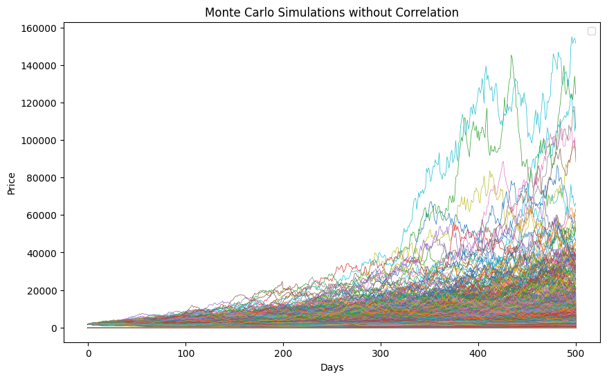

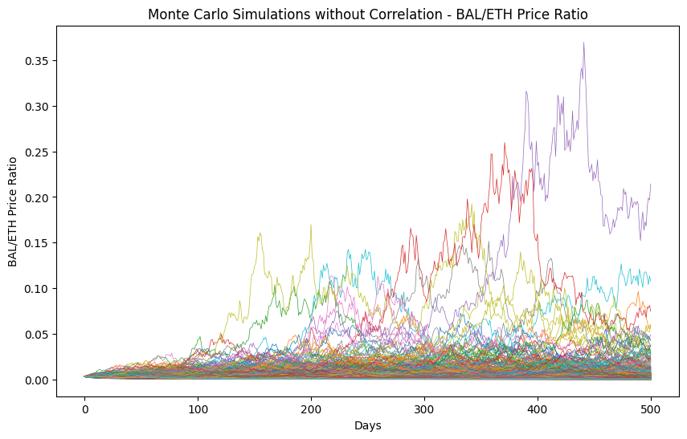

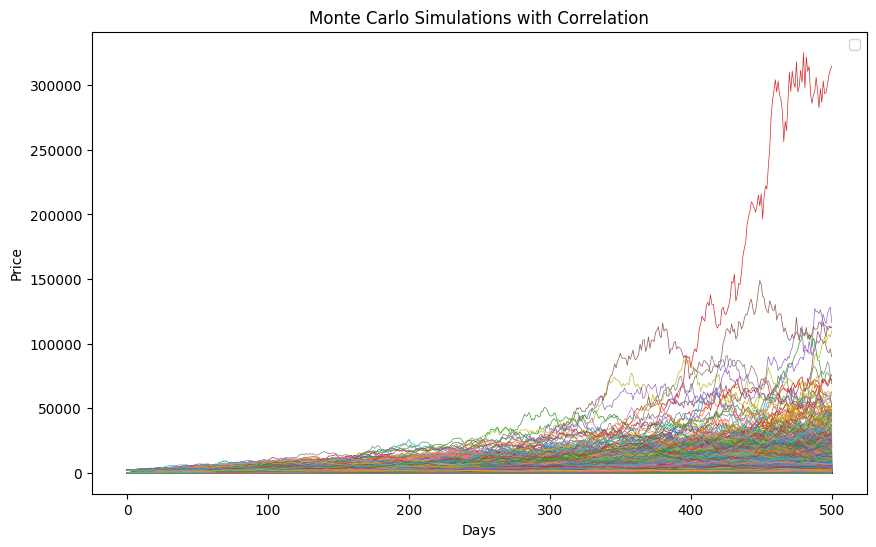

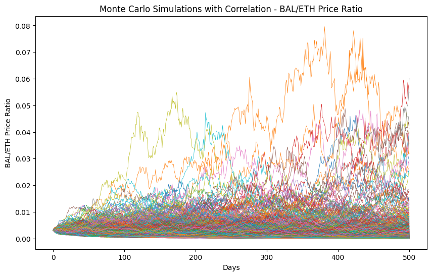

```python
import numpy as np
import matplotlib.pyplot as plt

# Number of simulations and time steps
num_simulations = 1000
num_days = 500

# Define the impermanent loss function
def compute_impermanent_loss(rho, weights):
    return (np.prod((1 + rho)**weights) / (1 + np.sum(weights * rho))) - 1

# Function to run Monte Carlo simulations
# Function to run Monte Carlo simulations
def run_monte_carlo_simulations(initial_prices, mean_returns, std_returns, correlation, num_simulations, num_days):
    # Create an array to store the simulated price paths
    simulations = np.zeros((num_days + 1, len(initial_prices), num_simulations))

    # Set the initial prices
    simulations[0, :, :] = initial_prices.reshape(-1, 1)

    # Generate correlated random returns (if correlation is not None)
    if correlation is not None:
        corr_matrix = np.array([[1, correlation], [correlation, 1]])
        L = np.linalg.cholesky(corr_matrix)

    # Run the simulations
    for t in range(1, num_days + 1):
        random_returns = np.random.normal(loc=mean_returns[:, np.newaxis], scale=std_returns[:, np.newaxis], size=(len(initial_prices), num_simulations))

        if correlation is not None:
            random_returns = L @ random_returns

        simulations[t, :, :] = simulations[t - 1, :, :] * (1 + random_returns)

    return simulations

# Run Monte Carlo simulations without and with the historical correlation coefficient
initial_prices = np.array([combined_df['price_BAL'].iloc[-1], combined_df['price_ETH'].iloc[-1]])
mean_returns = np.array([mean_return_BAL, mean_return_ETH])
std_returns = np.array([std_return_BAL, std_return_ETH])

simulations_no_corr = run_monte_carlo_simulations(initial_prices, mean_returns, std_returns, None, num_simulations, num_days)
simulations_with_corr = run_monte_carlo_simulations(initial_prices, mean_returns, std_returns, correlation, num_simulations, num_days)

# Plot the simulations
def plot_simulations(simulations, title, asset_ratios=False):
    plt.figure(figsize=(10, 6))

    if asset_ratios:
        simulations = simulations[:, 0, :] / simulations[:, 1, :]
        plt.ylabel('BAL/ETH Price Ratio')
    else:
        plt.ylabel('Price')
        plt.legend(['BAL', 'ETH'])

    for i in range(simulations.shape[1]):
        plt.plot(simulations[:, i], linewidth=0.5)

    plt.title(title)
    plt.xlabel('Days')
    plt.show()

# Plot the simulations for individual assets and BAL/ETH price ratios
plot_simulations(simulations_no_corr, "Monte Carlo Simulations without Correlation", asset_ratios=False)
plot_simulations(simulations_no_corr, "Monte Carlo Simulations without Correlation - BAL/ETH Price Ratio", asset_ratios=True)

plot_simulations(simulations_with_corr, "Monte Carlo Simulations with Correlation", asset_ratios=False)
plot_simulations(simulations_with_corr, "Monte Carlo Simulations with Correlation - BAL/ETH Price Ratio", asset_ratios=True)


# The impermanent loss function for respective period
def compute_impermanent_loss(rho, weights):
    return (np.prod((1 + rho) ** weights) / (1 + np.sum(weights * rho))) - 1

# Calculate impermanent loss for each respective period
def calculate_impermanent_losses(simulations, weights):
    rho = simulations[1:] / simulations[:-1] - 1
    impermanent_losses = np.zeros((num_days, num_simulations))

    for i in range(num_simulations):
        for t in range(num_days):
            impermanent_losses[t, i] = compute_impermanent_loss(rho[t, :, i], weights)

    return impermanent_losses

# Calculate cumulative impermanent loss for each simulation (relative to starting value)
def calculate_cumulative_impermanent_losses(impermanent_losses):
    return np.array([1 - np.prod(1 - impermanent_losses[:i], axis=0) for i in range(1, len(impermanent_losses) + 1)])

# Calculate the average cumulative impermanent loss over time across all simulations
def calculate_average_cumulative_impermanent_losses(cumulative_impermanent_losses):
    return np.mean(cumulative_impermanent_losses, axis=1)

# Assuming 80-20 weight distribution for BAL and ETH
weights = np.array([0.8,0.2])

# Calculate impermanent losses for each respective period
impermanent_losses_no_corr = calculate_impermanent_losses(simulations_no_corr, weights)
impermanent_losses_with_corr = calculate_impermanent_losses(simulations_with_corr, weights)

# Calculate cumulative impermanent loss from t=0 to t=t_0
cumulative_impermanent_losses_no_corr = calculate_cumulative_impermanent_losses(impermanent_losses_no_corr)
cumulative_impermanent_losses_with_corr = calculate_cumulative_impermanent_losses(impermanent_losses_with_corr)

# Calculate average cumulative impermanent loss from t=0 to t=t_0 across all simulations
average_cumulative_impermanent_losses_no_corr = calculate_average_cumulative_impermanent_losses(cumulative_impermanent_losses_no_corr)
average_cumulative_impermanent_losses_with_corr = calculate_average_cumulative_impermanent_losses(cumulative_impermanent_losses_with_corr)
```

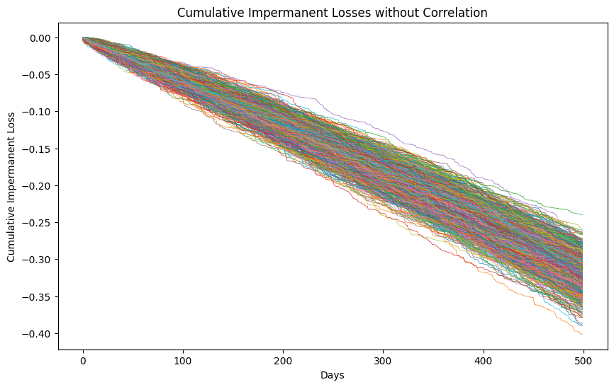

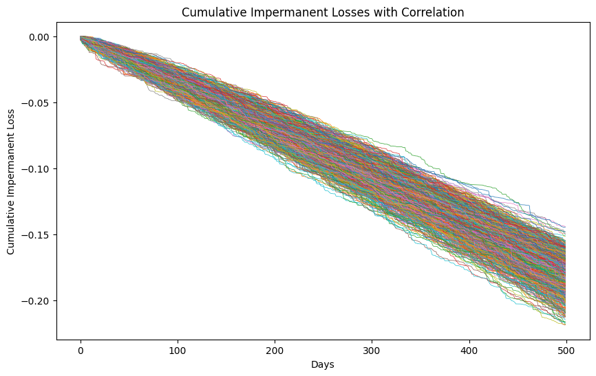

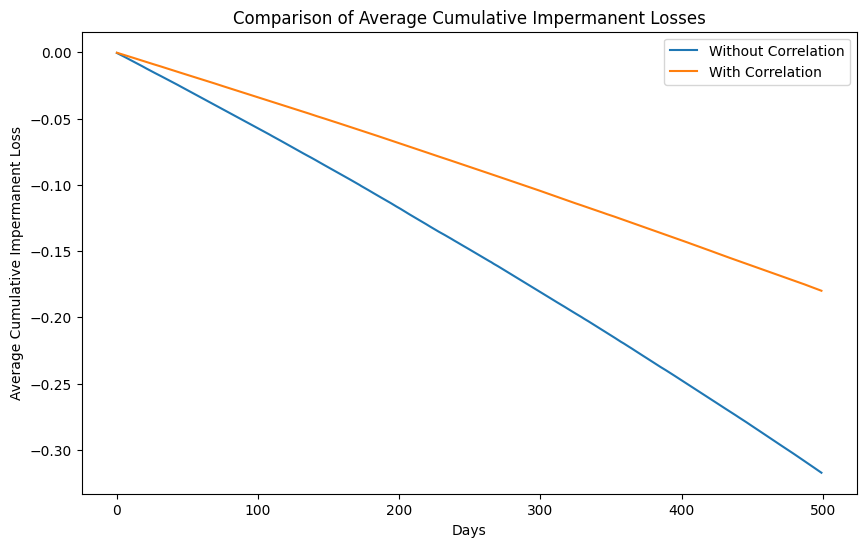

```python
def plot_cumulative_impermanent_losses(simulations, title):
    plt.figure(figsize=(10, 6))
    for i in range(simulations.shape[1]):
        plt.plot(simulations[:, i], linewidth=0.5)
    plt.xlabel('Days')
    plt.ylabel('Cumulative Impermanent Loss')
    plt.title(title)
    plt.show()

plot_cumulative_impermanent_losses(cumulative_impermanent_losses_no_corr, "Cumulative Impermanent Losses without Correlation")
plot_cumulative_impermanent_losses(cumulative_impermanent_losses_with_corr, "Cumulative Impermanent Losses with Correlation")

def plot_compared_average_cumulative_impermanent_losses(avg_losses_no_corr, avg_losses_with_corr):
    plt.figure(figsize=(10, 6))
    plt.plot(avg_losses_no_corr, label='Without Correlation')
    plt.plot(avg_losses_with_corr, label='With Correlation')
    plt.xlabel('Days')
    plt.ylabel('Average Cumulative Impermanent Loss')
    plt.title('Comparison of Average Cumulative Impermanent Losses')
    plt.legend()
    plt.show()

plot_compared_average_cumulative_impermanent_losses(average_cumulative_impermanent_losses_no_corr, average_cumulative_impermanent_losses_with_corr)
```

# Historical BAL-ETH IL

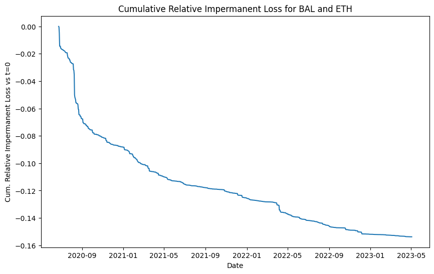

```python
# Assuming 80-20 weight distribution for BAL and ETH
# Following pool distribution for mainnet ETH-BAL LP deployed at 0x5c6Ee304399DBdB9C8Ef030aB642B10820DB8F56
weights = np.array([0.8,0.2])

# Extract historical prices for BAL and ETH from the combined DataFrame
historical_prices = combined_df[['price_BAL', 'price_ETH']].to_numpy()

# Calculate historical price changes
historical_price_changes = historical_prices[1:] / historical_prices[:-1] - 1

# Calculate the impermanent loss for each period between t-1 and t
impermanent_losses = np.array([compute_impermanent_loss(rho, weights) for rho in historical_price_changes])

# Calculate the cumulative impermanent loss for each period (relative to starting value)
cumulative_impermanent_losses = np.array([-(1 - np.prod(1 + impermanent_losses[:i])) for i in range(1, len(impermanent_losses) + 1)])

# Plot the cumulative impermanent loss over time
plt.figure(figsize=(10, 6))
plt.plot(combined_df['snapped_at'][1:], cumulative_impermanent_losses)
plt.xlabel('Date')
plt.ylabel('Cum. Relative Impermanent Loss vs t=0')
plt.title('Cumulative Relative Impermanent Loss for BAL and ETH')
plt.show()
```

# Appendix A: Coinmarketcap API access

Historical crypto assets price data can also be accessed via Coinmarketcap's API; the corresponding historical data API endpoint is however not part of the free API plan.

The below code snippet contains a first draft for how this data could be accessed via the API (not tested due to missing API permissions):

```python
# Get Coinmarket cap price data for BAL and WETH
import requests
import json
import pandas as pd
from datetime import datetime, timedelta

# Replace with your (paid) Coinmarketcap API key
# For sensitive API access, API secrets should be stored in environment variables and accessed with os.getenv
api_key = 'a49299ea-a64d-447a-8c6a-3e98682c65c2'

# Coin IDs for BAL and WETH
coin_ids = {
    'BAL': 5728,
    'WETH': 2396
}

# Function to get daily price data
def get_daily_price_data(coin_id, start_date, end_date):
    url = f'https://pro-api.coinmarketcap.com/v1/cryptocurrency/ohlcv/historical'
    headers = {
        'Accepts': 'application/json',
        'X-CMC_PRO_API_KEY': api_key
    }

    params = {
        'id': coin_id,
        'convert': 'USD',
        'time_start': start_date,
        'time_end': end_date,
        'interval': '1d'
    }

    response = requests.get(url, headers=headers, params=params)
    return response.json()

# Date range for fetching data
start_date = '2021-04-01'
end_date = '2023-04-30'

# Initialize empty DataFrame
price_data = pd.DataFrame(columns=['Date', 'Coin', 'Price'])

# Fetch and store daily price data for BAL and WETH in long format
for coin, coin_id in coin_ids.items():
    data = get_daily_price_data(coin_id, start_date, end_date)
    quotes = data['data']['quotes']

    for quote in quotes:
        date = datetime.fromtimestamp(quote['time_open']).strftime('%Y-%m-%d')
        price = quote['quote']['USD']['close']
        price_data = price_data.append({'Date': date, 'Coin': coin, 'Price': price}, ignore_index=True)

# Display the DataFrame
print(price_data)
```